# ausplotsR: quickstart guide to basic analysis of TERN AusPlots vegetation data

Greg Guerin & Bernardo Blanco-Martin

2023-11-17

## Introduction

TERN AusPlots is a national plot-based terrestrial ecosystem surveillance monitoring method and dataset for Australia (Sparrow et al. 2020). Through **ausplotsR**, users can directly access AusPlots data collected by on-ground observers on vegetation and soils, including physical sample/voucher details and barcode numbers. The dataset can be downloaded in its entirety or as individual modules, or as a subset by geographic bounding box or species name or site search. The package also includes a series of bespoke functions for working with AusPlots data, including visualisation, creating tables of species composition, and calculation of tree basal area, fractional cover or vegetation cover by growth form/structure/strata and so on.

This is a short guide for getting started with analysis of AusPlots data through the **ausplotsR** R package. More information on making use of AusPlots data in **ausplotsR** is available through the package help files and manual. Below, we demonstrate installing the package, accessing some AusPlots data, generating matrices and running simple example analyses.

More comprehensive (but not necessarily updated) tutorials on accessing and analysing AusPlots data (Blanco-Martin 2019) are available at: https://github.com/ternaustralia/TERN-Data-Skills/tree/master/EcosystemSurveillance_PlotData

## Installing the package and accessing raw data

The latest version of **ausplotsR** can be installed from CRAN or directly from github using the `devtools` package, which must be installed first.

```
library(devtools)
install_github("ternaustralia/ausplotsR", build_vignettes = TRUE, dependencies = TRUE)
```

Once installed, load the package as follows. Note, packages ggplot2 and mapdata are required for **ausplotsR** to load, and functions are also imported from packages: vegan, plyr, R.utils, httr, jsonlite, gtools, jose, curl, r2r, stringr, and betapart, while knitr and rmarkdown are required to build this package vignette (i.e., if ‘build_vignettes’ is set to TRUE above).

```r
library(ausplotsR)
```

We can now access live data, starting here with basic site information and vegetation point-intercept modules and using a bounding box to spatially filter the dataset to central Australia. All data modules are extracted via a single function, `get_ausplots`:

```r
# See ?get_ausplots to explore all data modules available
```

```r
my.ausplots.data <- try(get_ausplots(veg.PI = TRUE, veg.vouchers = TRUE, bounding_box = c(125,
    140, -40, -10)))
```

```
#> Calling the database. Please wait...
#> 200
#> Calling the database. Please wait...
#> 200
#> Calling the database. Please wait...
#> 200
#> Calling the database. Please wait...
#> 200
```

The output of the above call is a list with the following `$elements`:

```r
names(my.ausplots.data)
```

```
#> [1] "site.info" "veg.vouch" "veg.PI"    "citation"
```

The ‘site.info’ table contains basic site and visit details. Here are a selected few of the many fields:

```r
head(my.ausplots.data$site.info[, c("site_location_name", "site_unique", "longitude",
    "latitude", "bioregion_name")])
```

```
#>   site_location_name      site_unique longitude  latitude bioregion_name
#> 1         NTAARP0001 NTAARP0001-58422  132.2701 -13.55729            ARP
#> 2         NTAARP0002 NTAARP0002-58423  132.2944 -13.54561            ARP
#> 3         NTAARP0003 NTAARP0003-58424  132.4571 -13.51697            ARP
#> 4         NTAARP0004 NTAARP0004-58918  132.9865 -12.69178            ARP
#> 5         NTAARP0004 NTAARP0004-58932  132.9865 -12.69178            ARP
#> 6         NTAARP0005 NTAARP0005-58919  132.9850 -12.72723            ARP
```

**Each survey is identified by the *‘site_unique’* field, which is unique combination of site ID (‘site_location_name’) and visit ID (‘site_location_visit_id’). The *‘site_unique’* field therefore links all tables returned from the `get_ausplots` function**.

The ‘site.info’ table and can be used to identify, subset or group surveys in space and time, for example:

```r
# count plot visits per Australian States:
summary(as.factor(my.ausplots.data$site.info$state))
```

```
#>  NT QLD  SA  WA
#> 185  48 214  33
```

## Map AusPlots sites and visualise data

The package has an in-built function - see `?ausplots_visual` - to rapidly map AusPlots over Australia and to visualise the relative cover/abundance of green vegetation, plant growth forms and species. Maps can also be generated manually using the longitude and latitude fields in the `$site.info` table.

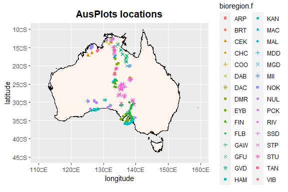

```r
# Sites are coded by IBRA bioregion by default.
map_ausplots(my.ausplots.data)
```

Alternatively, the following call generates a pdf with a map of all sites and attribute graphics for selected AusPlots: `ausplotsR::ausplots_visual()`

Here is a snippet of the raw point-intercept data that will be used in the following examples to derive vegetation attributes:

```r
head(subset(my.ausplots.data$veg.PI, !is.na(herbarium_determination)))
```

```
#>        site_unique site_location_name site_location_visit_id transect
#> 2 SAARIV0007-57096         SAARIV0007                  57096    S1-N1
#> 3 SAARIV0007-57096         SAARIV0007                  57096    S1-N1
#> 5 SAARIV0007-57096         SAARIV0007                  57096    S1-N1
#> 6 SAARIV0007-57096         SAARIV0007                  57096    S1-N1
#> 7 SAARIV0007-57096         SAARIV0007                  57096    S1-N1
#> 9 SAARIV0007-57096         SAARIV0007                  57096    S1-N1
#>   point_number herbarium_determination substrate in_canopy_sky  dead
#> 2            1         Duma florulenta    Litter         FALSE  TRUE
#> 3            2         Duma florulenta       CWD         FALSE FALSE
#> 5            4         Duma florulenta    Litter         FALSE  TRUE
#> 6            5         Duma florulenta    Litter         FALSE FALSE
#> 7            6         Duma florulenta    Litter         FALSE FALSE
#> 9            8         Duma florulenta      Bare         FALSE  TRUE
#>   growth_form height veg_barcode standardised_name
```

[output cut: 41 more lines]

Note that ‘veg_barcode’ links species hits to the vegetation vouchers module, while the ‘hits_unique’ field identifies the individual point-intercept by transect and point number (see `help(ausplotsR)` and references for more details on the plot layout and survey method). At each point, plant species (if any), growth form and height are recorded along with substrate type.

## Example 1: latitudinal pattern in proportional vegetation cover

Let’s visualise basic vegetation cover as a function of latitude. First, we call the `fractional_cover` function on the extracted point-intercept data (`$veg.PI`). The function converts the raw data to proportional cover of green/brown vegetation and bare substrate. Note the calculation may take a few minutes for many AusPlots, so for this example we will pull out a subset of 100 randomly drawn sites to work with.

```r
sites100 <- my.ausplots.data$veg.PI[which(my.ausplots.data$veg.PI$site_unique %in%
    sample(my.ausplots.data$site.info$site_unique, 100)), ]
my.fractional <- fractional_cover(sites100)

head(my.fractional)
```

```
#>                       site_unique bare brown green other
#> NTAARP0004-58932 NTAARP0004-58932  4.8   9.7  85.5   0.0
#> NTABRT0001-58861 NTABRT0001-58861 25.2  33.8  41.0   0.0
#> NTABRT0002-53617 NTABRT0002-53617 11.8  25.7  61.5   1.0
#> NTABRT0002-58862 NTABRT0002-58862 14.9  41.3  43.9   0.0
#> NTABRT0004-58873 NTABRT0004-58873 19.5  53.6  26.6   0.3
#> NTABRT0005-58863 NTABRT0005-58863 57.8  15.1  27.0   0.0
```

Next, we need to merge the fractional cover scores with longlat coordinates from the site information table. We use the ‘site_unique’ field (unique combination of site and visit IDs) to link tables returned from the `get_ausplots` function:

```r
my.fractional <- merge(my.fractional, my.ausplots.data$site.info, by = "site_unique")[,
    c("site_unique", "bare", "brown", "green", "other", "longitude", "latitude")]

my.fractional <- na.omit(my.fractional)

head(my.fractional)
```

```
#>        site_unique bare brown green other longitude  latitude
#> 1 NTAARP0004-58932  4.8   9.7  85.5   0.0  132.9865 -12.69178
#> 2 NTABRT0001-58861 25.2  33.8  41.0   0.0  133.2473 -22.28360
#> 3 NTABRT0002-53617 11.8  25.7  61.5   1.0  133.2506 -22.28367
#> 4 NTABRT0002-58862 14.9  41.3  43.9   0.0  133.2506 -22.28367
#> 5 NTABRT0004-58873 19.5  53.6  26.6   0.3  133.6164 -22.28981
#> 6 NTABRT0005-58863 57.8  15.1  27.0   0.0  133.6121 -22.29108
```

Now we can plot out the continental relationship, e.g., between the proportion of bare ground with no kind of vegetation cover above and latitude.

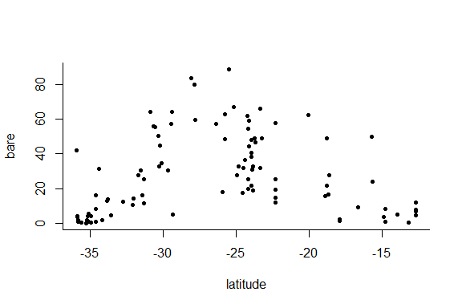

```r
plot(bare ~ latitude, data = my.fractional, pch = 20, bty = "l")
```

There appears to be a hump-backed relationship, with a higher proportion of bare ground in the arid inland at mid-latitudes. We can add a simple quadratic model to test/approximate this:

```r
my.fractional$quadratic <- my.fractional$latitude^2

LM <- lm(bare ~ latitude + quadratic, data = my.fractional)
summary(LM)
```

```
#>
#> Call:
#> lm(formula = bare ~ latitude + quadratic, data = my.fractional)
#>
#> Residuals:
#>     Min      1Q  Median      3Q     Max
#> -31.406 -11.507  -3.629  11.302  45.844
#>
#> Coefficients:
#>               Estimate Std. Error t value Pr(>|t|)
#> (Intercept) -152.97447   23.22856  -6.586 2.49e-09 ***
#> latitude     -15.80834    1.91325  -8.263 8.40e-13 ***
#> quadratic     -0.31863    0.03757  -8.481 2.89e-13 ***
#> ---
#> Signif. codes:  0 '***' 0.001 '**' 0.01 '*' 0.05 '.' 0.1 ' ' 1
#>
#> Residual standard error: 17.44 on 95 degrees of freedom
#> Multiple R-squared:  0.4345, Adjusted R-squared:  0.4226
#> F-statistic: 36.49 on 2 and 95 DF,  p-value: 1.744e-12
```

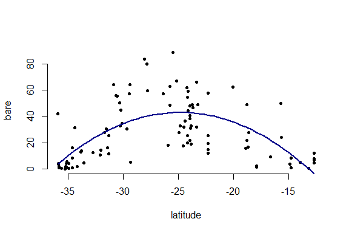

```r
# generate predicted values for plotting:
MinMax <- c(min(my.fractional$latitude), max(my.fractional$latitude))
ND <- data.frame(latitude = seq(from = MinMax[1], to = MinMax[2], length.out = 50),
    quadratic = seq(from = MinMax[1], to = MinMax[2], length.out = 50)^2)
ND$predict <- predict(LM, newdata = ND)
#
plot(bare ~ latitude, data = my.fractional, pch = 20, bty = "n")
points(ND$latitude, ND$predict, type = "l", lwd = 2, col = "darkblue")
```

## Example 2: Species by sites table

Aside from ‘gross’ values from plots such as fractional cover, many analyses in community ecology begin with species abundance information. With **ausplotsR** you can generate this easily from the more complex vegetation point-intercept data. The first step to work with species-level AusPlots data is to create a species occurrence matrix. The `species_table` function in the **ausplotsR** package can be used to create this type of matrix. This function takes a data frame of individual raw point-intercept hits (i.e. a `$veg.PI` data frame) generated using the `get_ausplots` function and returns a ‘species against sites’ matrix:

```r
# The species_table function below can also take the `$veg.voucher` module as
# input, but `m_kind='PA'` must be specified to get a sensible presence/absence
# output.
```

```r
# The 'species_name' argument below specifies use of the 'standardised_name'
# field to identify species, which is based on herbarium_determination names
# (i.e., 'HD' option in species_name) matched to accepted scientific name
# according to a standard (APC:
# https://www.anbg.gov.au/cpbr/program/hc/hc-APC.html).
```

```r
my.sppBYsites <- species_table(my.ausplots.data$veg.PI, m_kind = "percent_cover",
    cover_type = "PFC", species_name = "SN")

# check the number of rows (plots) and columns (species) in the matrix
dim(my.sppBYsites)
```

```
#> [1]  473 2187
```

```r
# look at the top left corner (as the matrix is large)
my.sppBYsites[1:5, 1:5]
```

```
#>                  Abutilon Abutilon.fraseri Abutilon.halophilum Abutilon.hannii
#> NTAARP0001-58422        0                0                   0               0
#> NTAARP0002-58423        0                0                   0               0
#> NTAARP0003-58424        0                0                   0               0
#> NTAARP0004-58918        0                0                   0               0
#> NTAARP0004-58932        0                0                   0               0
#>                  Abutilon.hannii.subsp..prostrate..p.k.latz.427.
#> NTAARP0001-58422                                               0
#> NTAARP0002-58423                                               0
#> NTAARP0003-58424                                               0
#> NTAARP0004-58918                                               0
#> NTAARP0004-58932                                               0
```

We can crudely pull out the 10 highest ranking species in terms of their percent cover cumulative across all plots they occur in:

```r
rev(sort(colSums(my.sppBYsites)))[1:10]
```

```
#>                      Na       Triodia.basedowii   Eucalyptus.tetrodonta
#>                   672.8                   634.1                   417.6
#>         Triodia.pungens                 Poaceae       Triodia.bitextura
#>                   412.6                   395.7                   389.4
#> Eucalyptus.diversifolia      Eucalyptus.baxteri      Eucalyptus.obliqua
#>                   386.2                   381.7                   370.0
#>       Cenchrus.ciliaris
#>                   346.8
```

A simple example of downstream visualisation and analysis of species-level AusPlots data is Rank-Abundance Curves (also known as Whittaker Plots). Rank-Abundance Curves provide further information on species diversity. They provide a more complete picture than a single diversity index. Their x-axis represents the abundance rank (from most to least abundant) and in the y-axis the species relative abundance. Thus, they depict both Species Richness and Species Evenness (slope of the line that fits the rank; steep gradient indicates low evenness and a shallow gradient high evenness).

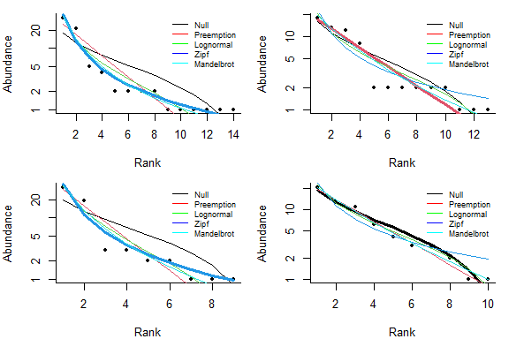

```r
# Whittaker plots for some selected AusPlots with alternative relative
# abundance models fitted to the plant community data:
par(mfrow = c(2, 2), mar = c(4, 4, 1, 1))
for (i in c(1:4)) {
    plot(vegan::radfit(round(my.sppBYsites[9 + i, ], digits = 0), log = "xy"), pch = 20,
        legend = FALSE, bty = "l")
    legend("topright", legend = c("Null", "Preemption", "Lognormal", "Zipf", "Mandelbrot"),
        lwd = rep(1, 5), col = c("black", "red", "green", "blue", "cyan"), cex = 0.7,
        bty = "n")
}
```

## Example 3: Quick species lists

Perhaps you simply want to browse which plant species have been recorded in AusPlots, without all the associated raw data? Here, the `species_list` function is your friend:

```r
# The species_list function is designed to take $veg.voucher as input but can
# also take $veg.PI
```

```r
# print a list of genus_species-only records from selected plots (for
# demonstration we print only part):
species_list(my.ausplots.data$veg.vouch, grouping = "by_site", species_name = "GS")[1:2]
```

```
#> $NTAARP0001
#>  [1] Acacia alleniana
#>  [2] Acacia cowleana
#>  [3] Acacia dimidiata
#>  [4] Acacia lamprocarpa
#>  [5] Acacia mimula
#>  [6] Alphitonia excelsa
#>  [7] Aristida longicollis
#>  [8] Arthrostylis aphylla
#>  [9] Blumea saxatilis
#> [10] Bonamia brevifolia
#> [11] Boronia decumbens
#> [12] Brachychiton megaphyllus
#> [13] Breynia cernua
#> [14] Buchanania obovata
```

[output cut: 125 more lines]

```r
# overall species list ordered by family (for demonstration we print only
# part):
species_list(my.ausplots.data$veg.vouch, grouping = "collapse", species_name = "SN",
    append_family = TRUE)[1:50]
```

```
#>  [1] Abutilon cryptopetalum--Malvaceae
#>  [2] Abutilon fraseri subsp. fraseri--Malvaceae
#>  [3] Abutilon fraseri--Malvaceae
#>  [4] Abutilon halophilum--Malvaceae
#>  [5] Abutilon hannii subsp. prostrate (p.k.latz 427)--Malvaceae
#>  [6] Abutilon hannii--Malvaceae
#>  [7] Abutilon leucopetalum--Malvaceae
#>  [8] Abutilon macrum--Malvaceae
#>  [9] Abutilon malvifolium--Malvaceae
#> [10] Abutilon otocarpum--Malvaceae
#> [11] Abutilon oxycarpum--Malvaceae
#> [12] Abutilon--Malvaceae
#> [13] Acacia acinacea--Fabaceae
#> [14] Acacia adoxa--Fabaceae
#> [15] Acacia adsurgens--Fabaceae
```

[output cut: 35 more lines]

## Explore TERN AusPlots

In addition to the key site info and vegetation point-intercept modules introduced above, `get_ausplots` is your gateway to raw data modules for vegetation structural summaries, vegetation vouchers (covers the full species diversity observed at the plot and includes tissue sample details), basal wedge, and soils subsites, bulk density and pit/characterisation (including bulk and metagenomics soil samples).

## References

Blanco-Martin, B. (2019) Tutorial: Understanding and using the ‘ausplotsR’ package and AusPlots data. Terrestrial Ecology Research Network. Version 2019.04.0, April 2019. https://github.com/ternaustralia/TERN-Data-Skills/

Sparrow, B., Foulkes, J., Wardle, G., Leitch, E., Caddy-Retalic, S., van Leeuwen, S., Tokmakoff, A., Thurgate, N., Guerin, G.R. and Lowe, A.J. (2020) A vegetation and soil survey method for surveillance monitoring of rangeland environments. *Frontiers in Ecology and Evolution*, 8:157.